# **Thesis Empirical Results**

In this notebook, I describe my empirical findings concerning the error term of the Polya-Vinogradov Inequality. At a high level, I generated data for a sample of primes and then analyzed that data. This report will contain the major results. I also have a notebook in my repo called data_analysis.ipynb that includes all of my data analysis.

# **Table of Contents**

| No | Contents | No | Contents |
| --- | --- | --- | --- |
| 1 | Problem Background | 6 | Investigating Magnitude Diff/Dist Check |
| 2 | Data Description | 7 | Investigating Prime Mod 4 |
| 3 | Data Setup | 8 | Difference List Analysis |
| 4 | Diff Plot Examples | 9 | Conclusion |
| 5 | Basic EDA |  |  |

# **Problem Background**

Define $S_p(x) := \sum_{a \leq x} \left( \frac{a}{p} \right)$ to be the character sum of legendre symbols. In other words, the character sum is the partial sum of Legendre symbols. A famous inequality, known as the *Polya-Vinogradov* Inequality, gives us the following bound: $$ |S_p(x)| \leq \sqrt{p} \log p. $$ One way to prove this involves using *Polya's Fourier Expansion* : $$ S_p(x) = \frac{G(p)}{2\pi i} \sum_{i \leq |n| \leq H} \left( \frac{n}{p} \right) \frac{[1 - e(\frac{-nx}{p})]}{n} + O\left(\frac{p \log p}{H}\right) + O(1), $$ where $$ G(p) = \begin{cases} \sqrt{p} & \text{ if } p \equiv 1 \ (\textrm{mod } 4) \\ i \sqrt{p} & \text{ if } p \equiv -1 \ (\textrm{mod } 4). \end{cases} $$

It turns out if you instantiate $H = (\log p)^2$, you get the following: $$ S_p(x) = C\sqrt{p} \cdot \log \log p + O\left(\frac{p}{\log p}\right). $$ Notice that if the error term is smaller than we improve the Polya-Vinogradov Inequality! This is the ambitious ultimate goal, and a starting point was to generate numerics to see what this error term actually looks like, which is what this notebook showcases.

# **Data Description**

First let's go through a bit of notation. We let $S(x)$ be the character sum of legendre symbols, and $F(x)$ be the main term of Polya's Fourier Expansion. We are interested in the max (or min) of $$D(x) := S(x) - F(x).$$

Specifically, I collected data for around $135$ primes, with $2$ being around $1,000,000$ and the rest being sampled uniformly at random from $100,000- 200,000$. For each prime $p$ I record the following pieces of info:

- prime : p
- pos_error : max(D(x))
- neg_error : min(D(x))
- x_pos_error : 100 * (argmax(D(x)) / prime)
- x_neg_error : 100 * (argmin(D(x)) / prime)
- max_error : max(pos_error, -1 $\cdot$ neg_error)
- max_error_ind: 1 if max_error == pos_error else 0
- x_max_error : x_pos_error if max_error_ind == 1 else x_neg_error
- mag_diff : |pos_error + neg_error|
- dist_check : |100 - x_pos_error - x_neg_error|
- mod_4 : prime (mod 4)

Additionally, I also create a "diff plot", which is simply a scatterplot of $D(x)$ vs. $x$.

Most of these are intuitive things to look at. It doesn't really make sense to look at mag_diff or dist_check, though it will be clear by the exploratory data analysis (EDA) that this is a natural thing to study. Further, it turns out that mod_4 is the most important feature; the diff plots become much clearer when considering this feature.

# **Data Setup**

```python
import os
import random

from PIL import Image
import numpy as np
import pandas as pd
import matplotlib.pyplot as plt
```

```python
path     = os.path.join("/Users", "jcheigh", 'Thesis')
csv_name = f"{path}/final.csv"

df = pd.read_csv(csv_name, index_col = False)
df.head()
```

|  | prime | pos_error | neg_error | x_pos_error | x_neg_error | max_error | max_error_ind | x_max_error | mag_diff | mod_4 | dist_check |
| --- | --- | --- | --- | --- | --- | --- | --- | --- | --- | --- | --- |
| 0 | 101359 | 27.71 | -17.25 | 46.34122 | 30.89908 | 27.71 | 1 | 46.34122 | 10.46 | 3 | 22.76 |
| 1 | 102653 | 23.70 | -23.62 | 50.34436 | 49.65271 | 23.70 | 1 | 50.34436 | 0.08 | 1 | 0.00 |
| 2 | 102859 | 24.54 | -22.80 | 14.94181 | 69.65069 | 24.54 | 1 | 14.94181 | 1.74 | 3 | 15.41 |
| 3 | 104479 | 17.74 | -27.27 | 58.53617 | 87.80329 | 27.27 | 0 | 87.80329 | 9.53 | 3 | 46.34 |
| 4 | 104759 | 51.11 | -0.00 | 52.31436 | 99.99809 | 51.11 | 1 | 52.31436 | 51.11 | 3 | 52.31 |

```python
def plot(prime = None, name = None):
    if prime is None and name is None:
        raise ValueError("At least one of prime and name shouldn't be None")

    if isinstance(prime, str):
        name = prime
        prime = None

    plot_path = os.path.join(path, "plots")

    if prime is None:
        plot = f"{plot_path}/{name}.png"
        if not os.path.exists(plot):
            raise IOError("Plot path doesn't exist")

    if name is None:
        plot = f"{plot_path}/Prime = {prime} Difference Plot.png"
        if not os.path.exists(plot):
            raise IOError(f"Prime = {prime} hasn't been analyzed yet")

    img = Image.open(plot)
    plt.figure(figsize = (20, 10))
    plt.imshow(img)
    plt.axis('off')
    plt.show()


lst_path = os.path.join(path, 'data')
get_lst_path = lambda prime : f'{lst_path}/Prime = {prime} Diff List.txt'

def get_lst(prime):
    path = get_lst_path(prime)

    with open(path, "r") as txt_file:
        lst = txt_file.read().splitlines()

    return [float(x) for x in lst]
```

# **Diff Plot Examples**

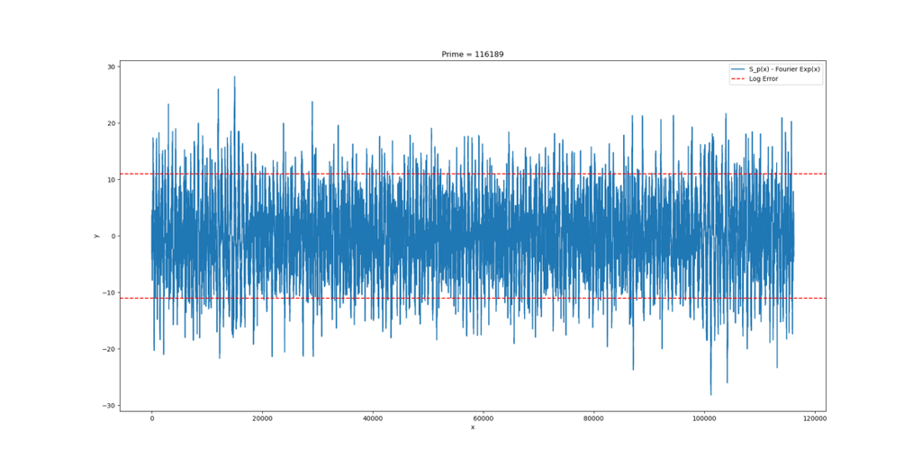

```python
p1, p2, p3 = 116189, 183247, 104759

plot(p1)
```

**Plot Analysis:**

- This is an example of a "diff plot" for p = 116189
- Here we can see the max positive error for this prime is ~28
- The red lines indicate log error (big-O constant == 1)
- There seems to be some antisymmetry here (over x == prime // 2 axis)

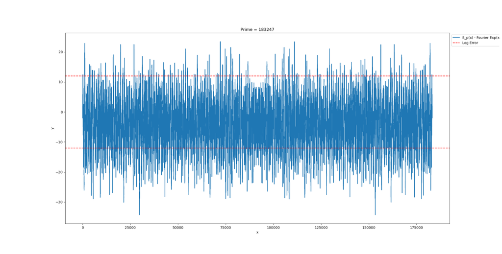

```python
plot(p2)
```

**Plot Analysis:**

- This plot is pretty similar
- But, rather than antisymmetry we have symmetry here

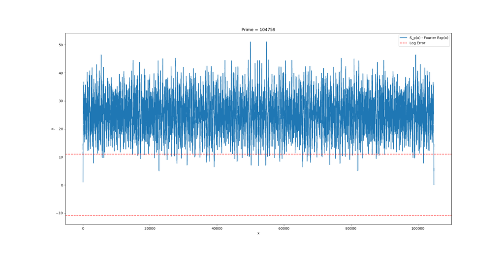

```python
plot(p3)
```

**Plot Analysis:**

- This one is weird
- We still have symmetry
- But there's also a big vertical translation here
- The mean error seems to be around 20-30, rather than 0

**Overall Analysis:**

- The diff plots seem similar to Brownian Motion
- There are definitely symmetry properties
- There are definitely translation properties

# **Basic EDA**

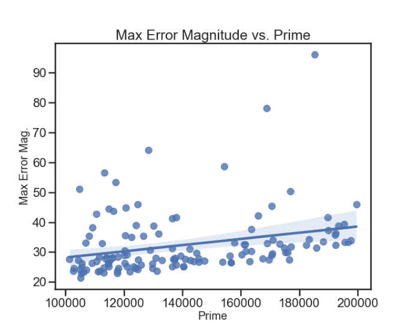

```python
plot("Max Error Mag. vs. Prime")
```

**Plot Analysis:**

- This is a scatterplot of prime vs. max error
- There's a positive association
- Most are in a pretty consistent range and then some outliers

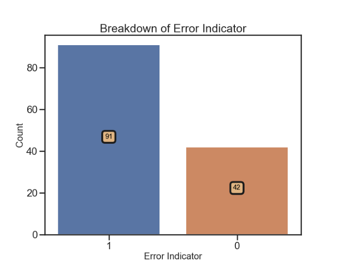

```python
plot("Max Error Indicator")
```

**Plot Analysis:**

- It turns out around 2/3 of the plots have higher pos_error than -1 * neg_error

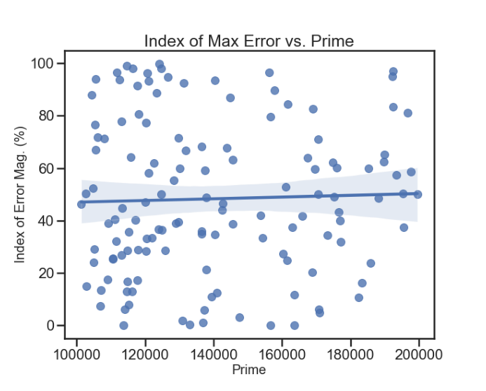

```python
plot("x_max_error vs. prime")
```

**Plot Analysis:**

- This shows where the max error occurs
- Seems pretty uniform

# **Investigating Magnitude Diff/Dist Check**

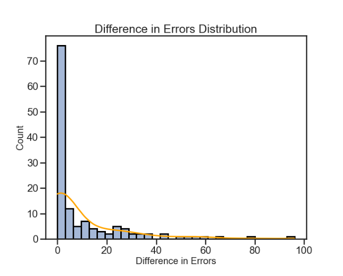

```python
plot("mag_diff distribution")
```

**Plot Analysis:**

- I created this feature while playing around with the data
- Interestingly, this seems like a semi-categorical feature
- It's almost binary whether it's mag_diff ~ 0 or mag_diff != 0
- Then for mag_diff != 0 there's a completely separate distribution
- Basically half have pos_error ~ -1 * neg_error

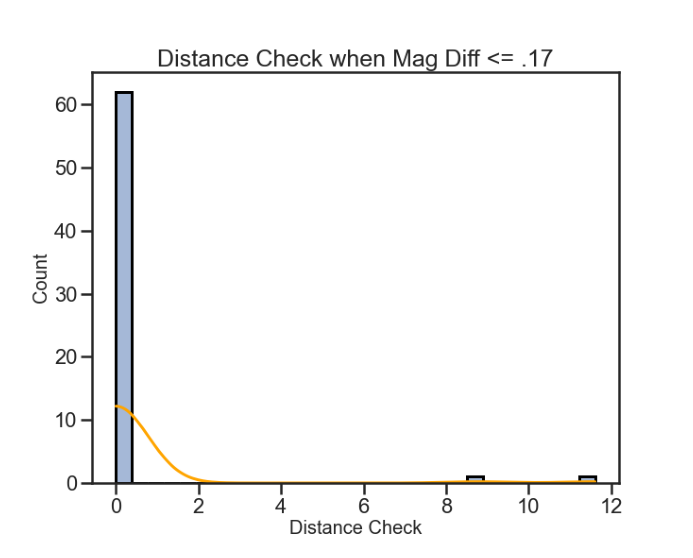

```python
plot('Dist Check')
```

**Plot Analysis:**

- This is really interesting
- pos_error ~ -1 * neg_error => indices are ~ equidistant from x = prime // 2
- The two exceptions here actually aren't really counterexamples either

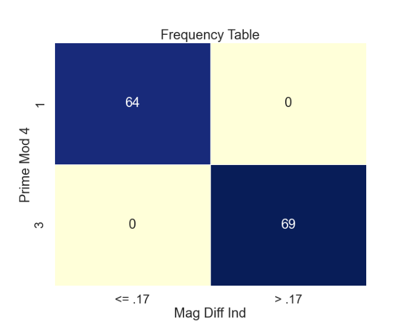

```python
plot("Frequency Table")
```

**Plot Analysis:**

- Here we see something really interesting
- *All* prime == 1 (mod 4) have "small" magnitude difference
- *All* prime == 3 (mod 4) have "large" magnitude difference

# **Investigating Prime Mod 4**

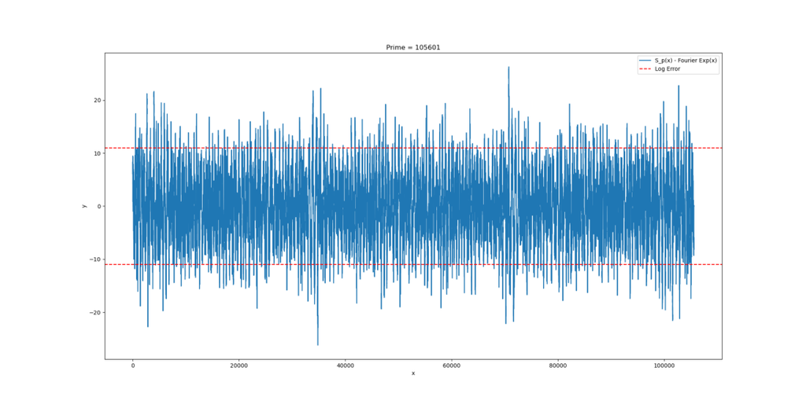

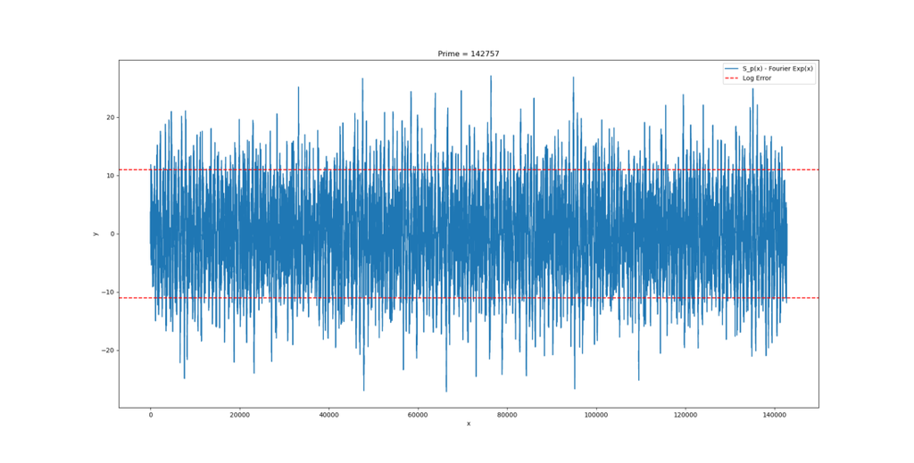

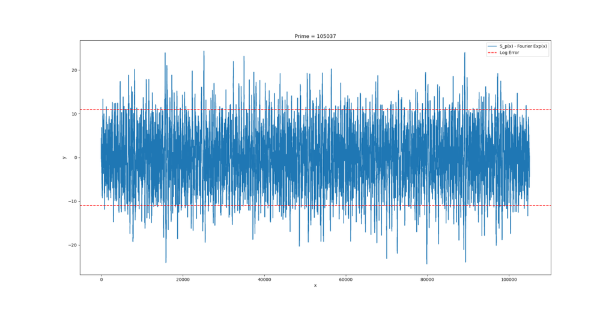

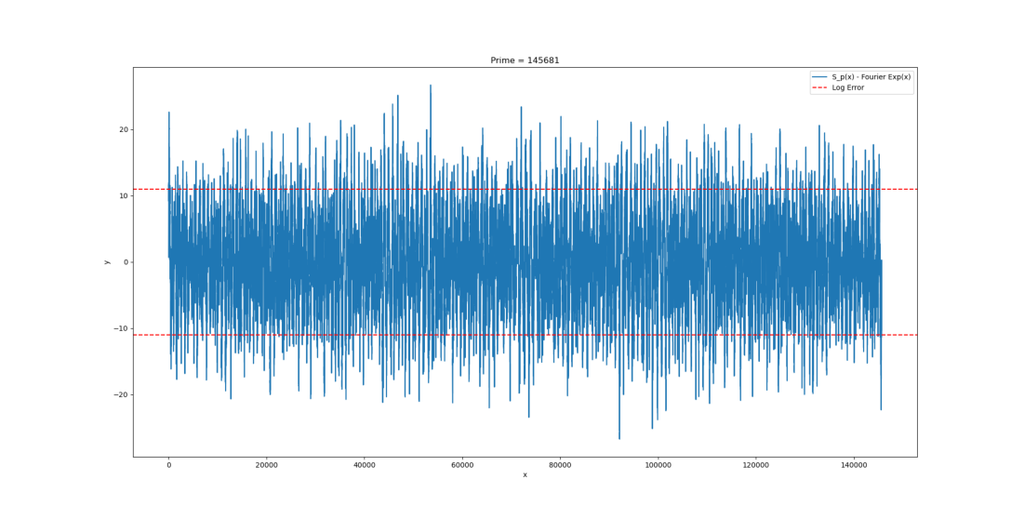

```python
mod3_primes = df[df["mod_4"] == 3]['prime'].values
mod1_primes = df[df["mod_4"] == 1]['prime'].values

for prime in random.choices(mod1_primes, k = 4):
    plot(prime)
```

**Plot Analysis:**

- From this sample it seems *all* primes == 1 (mod 4) have antisymmetry properties
- It also seems that all of these are centered at zero error, i.e. no vertical translation
- It turns out this is true for all primes I've generated!

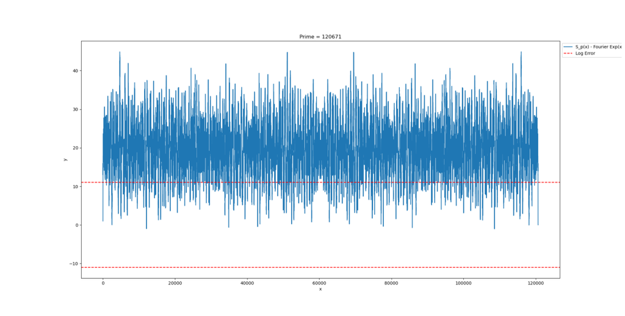

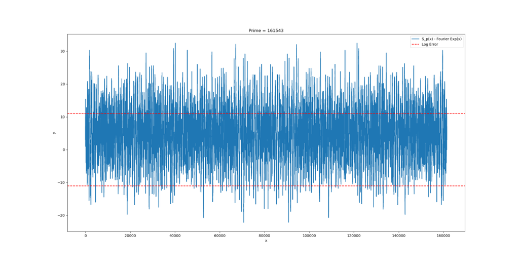

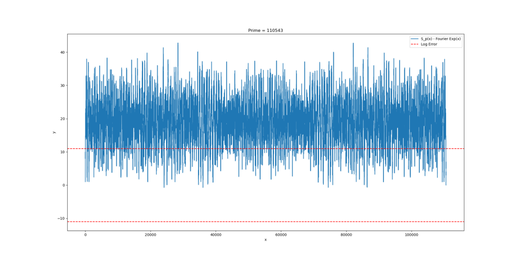

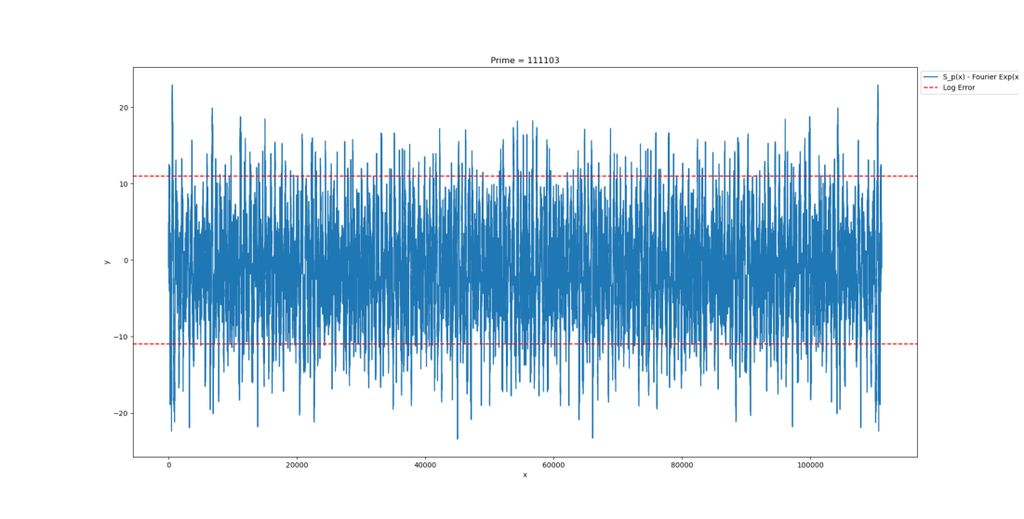

```python
for prime in random.choices(mod3_primes, k = 4):
    plot(prime)
```

**Plot Analysis:**

- From this sample it seems *all* primes == 3 (mod 4) have symmetry properties
- It also seems like there are some plots (not all!) with vertical translation
- It turns out this is true for all primes I've generated!

**Mod 4 Empirical Results:**

- symmetry if and only if prime == 3 (mod 4)
- antisymmetry if and only if prime == 1 (mod 4)
- if prime == 1 (mod 4), no vertical translation
- most (but not all) prime == 3 (mod 4) have vertical translation

# **Difference List Analysis**

Let's actually look at a few difference lists and see if we can quantify these trends we are seeing.

```python
large_prime_1 = get_lst(1020389) # large prime == 1 (mod 4)
large_prime_3 = get_lst(1000003) # large prime == 3 (mod 4)
small_prime_1 = get_lst(129749)  # small prime == 1 (mod 4)
small_prime_3 = get_lst(115151)  # small prime == 3 (mod 4)
```

```python
print(f"Mean of Large Prime 1 Diff List: {round(np.mean(large_prime_1), 15)}")
print(f"Mean of Small Prime 1 Diff List: {round(np.mean(small_prime_1), 15)}")

print(f"Mean of Large Prime 3 Diff List: {round(np.mean(large_prime_3), 2)}")
print(f"Mean of Small Prime 3 Diff List: {round(np.mean(small_prime_3), 2)}")
```

```
Mean of Large Prime 1 Diff List: 0.0
Mean of Small Prime 1 Diff List: -0.0
Mean of Large Prime 3 Diff List: 13.51
Mean of Small Prime 3 Diff List: 4.15
```

**Analysis:**

- We expected no vertical translation on the primes == 1 (mod 4)
- In reality they are almost exactly 0 (up to $> 15$ decimal places)
- We expected varying vertical translation on the primes == 3 (mod 4)
- In reality they have varying vertical translation (mean error $\neq 0$)

**Symmetry Check:**  
We have checked the translation property, and now it's time to check symmetry. Let $D$ be a difference list and $D(i)$ be the ith element of $D$. Then we get the following:

- Symmetry $\implies D(i) - D(-i) \approx 0$
- Antisymmetry $\implies D(i) + D(-i) \approx 0$

We expect the following:

- Sym Check plot $\approx 0$ for primes $\equiv 3\ (\mathrm{mod}\ 4)$
- AntiSym Check plot $\approx 0$ for primes $\equiv 1\ (\mathrm{mod}\ 4)$.

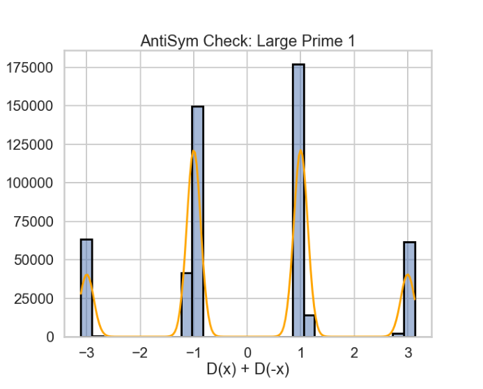

```python
plot("AntiSym Check: Large Prime 1")
```

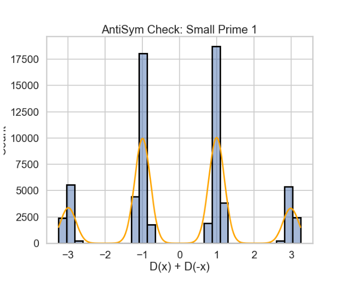

```python
plot("AntiSym Check: Small Prime 1")
```

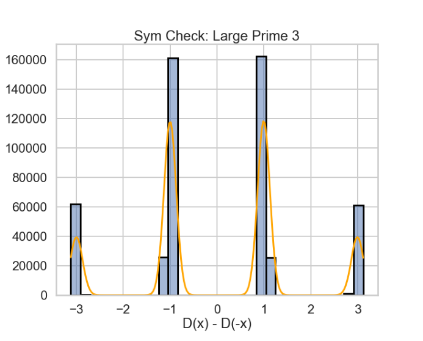

```python
plot("Sym Check: Large Prime 3")
```

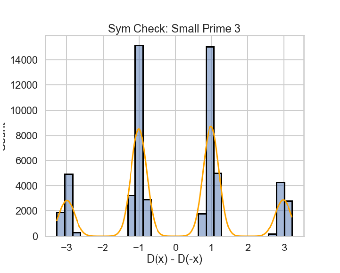

```python
plot("Sym Check: Small Prime 3")
```

**Plot Analysis:**

- These all are approximately $0$, as expected
- However, they all follow the same weird distribution
- I'm not sure why this happens and need to look into this more

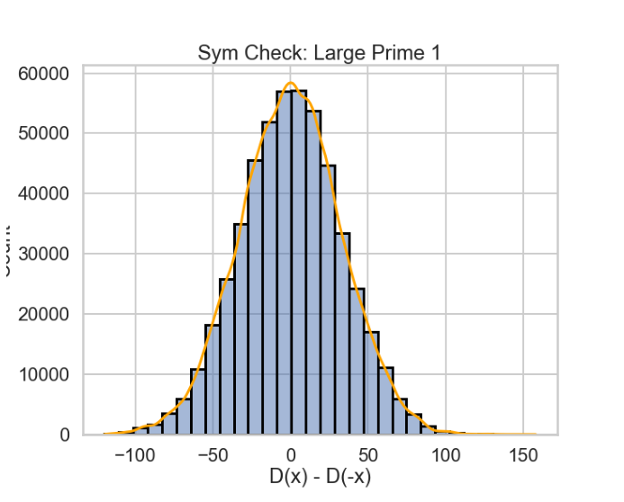

```python
plot("Sym Check: Large Prime 1")
```

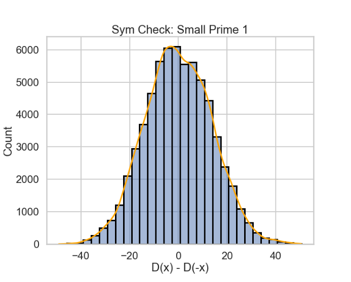

```python
plot("Sym Check: Small Prime 1")
```

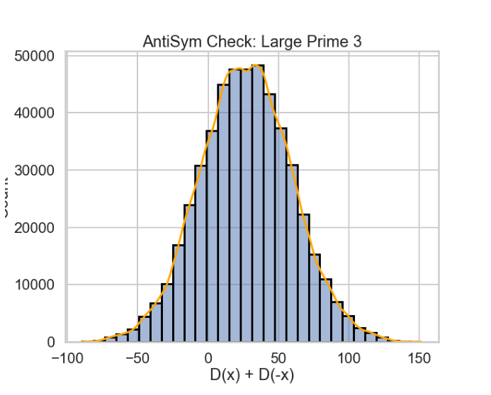

```python
plot("AntiSym Check: Large Prime 3")
```

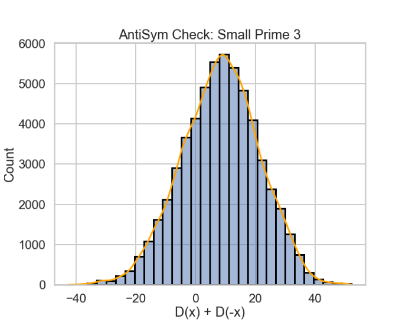

```python
plot("AntiSym Check: Small Prime 3")
```

**Plot Analysis:**

- These are the opposite (Sym check when we expect AntiSym and vice versa)
- Strangly, these are all seemingly normally distributed
- I also don't know what to make of this need to think more

# **Conclusion**

Essentially I found that the error always seems to stay within $O(\log p)$ (works if big-O constant is on the order of $10$). I also found that looking at the primes mod $4$ has a strange relations with translations and symmetries. However, it's important to not extrapolate too much.

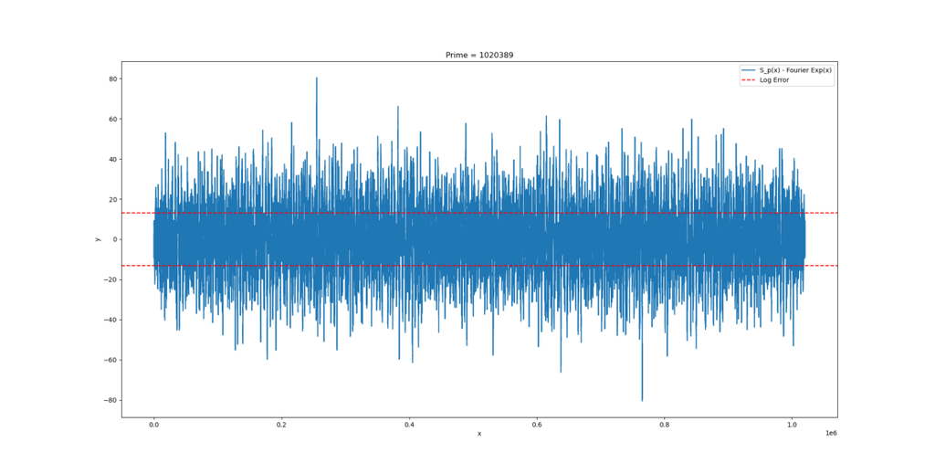

```python
plot(1020389)
```

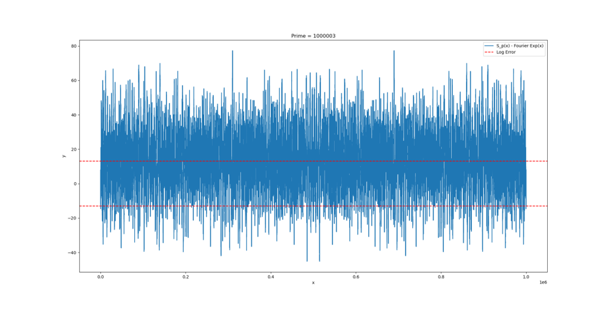

```python
plot(1000003)
```

**Plot Analysis:**

- Here are two diff plots for primes on the order of 1 million
- These, in contrast with smaller primes (100-200k), seem to have errors disproportionately higher
- In other words the behavior we see at 100-200k is definitely not convergent behavior
- Thus it's possible the error continues to grow or even explodes later on

We are interested in the max error and bounding that. The error seems to come from two components: one is the vertical translation (if you vertical translate up you have high error), one is the pseudorandom error (there are seemingly random spikes that can cause high error). So which of these is the dominating effect?

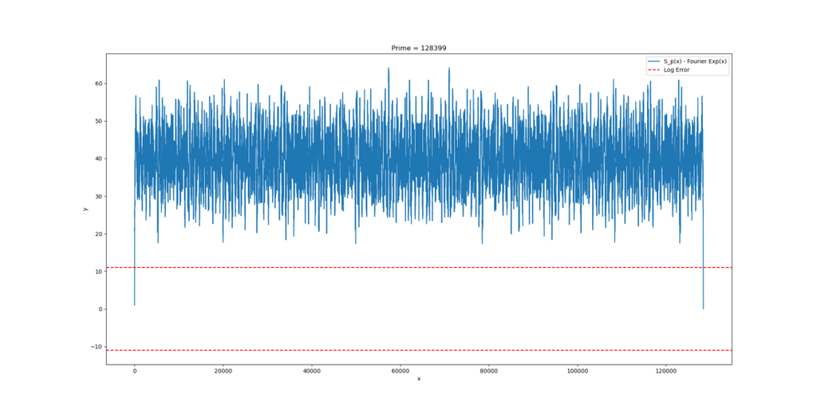

```python
plot(128399)
```

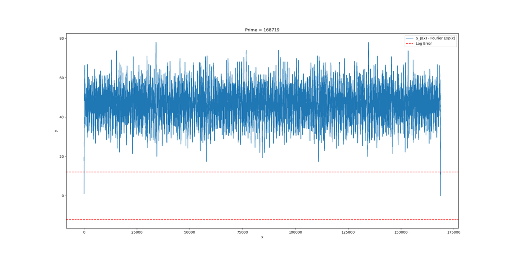

```python
plot(168719)
```

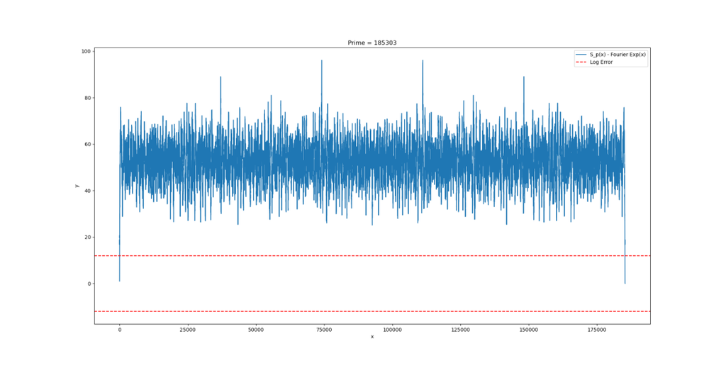

```python
plot(185303)
```

**Plot Analysis:**

- These are the 3 plots with the highest max error
- Here we see the max error from what we see is in fact due to translation
- Maybe it would be beneficial to break this problem into two (1 mod 4 and 3 mod 4)?